# Music EDX Capstone Project Report

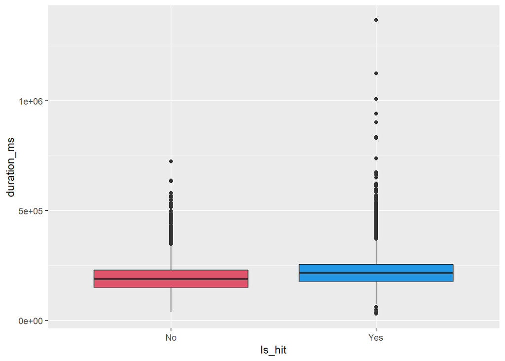

```r
#boxplot by class
training %>%
  ggplot(., aes(x=Is_hit, y=duration_ms)) +
  geom_boxplot( fill= c(2,4)) +
  xlab("Is_hit")
```

- relationship of tempo and valence :

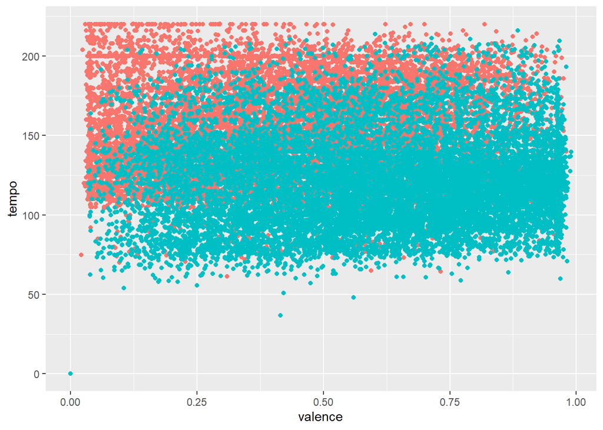

```r
#considering tempo and valence relationship
training %>%
  ggplot(., aes(x=valence, y=tempo, color=Is_hit)) +
  geom_point() +
  theme(legend.position="none")
```

- relationship of tempo and danceability :

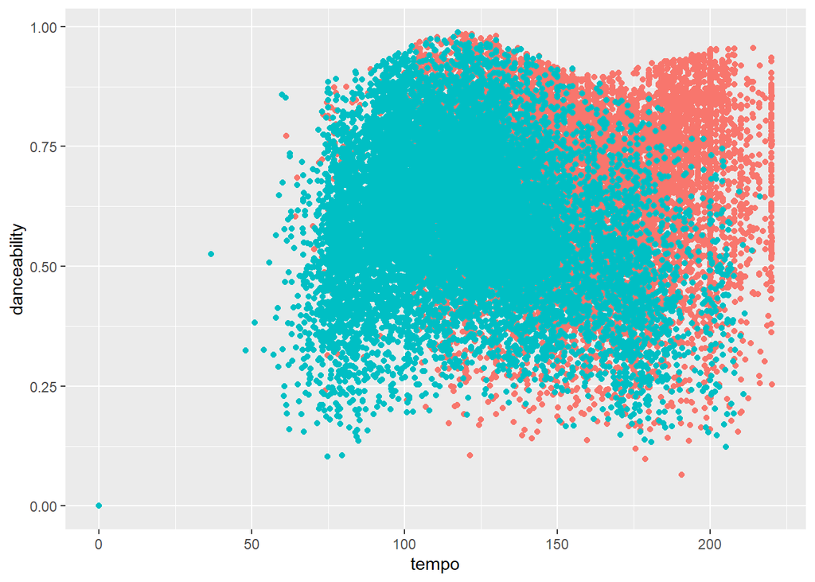

```r
#considering tempo and danceability relationship
training %>%
  ggplot(., aes(x=tempo, y=danceability, color=Is_hit)) +
  geom_point() +
  theme(legend.position="none")
```

- relationship of tempo and energy :

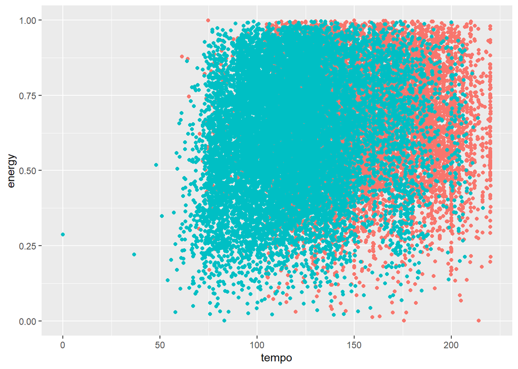

```r
#considering tempo and energy relationship
training %>%
  ggplot(., aes(x=tempo, y=energy, color=Is_hit)) +
  geom_point() +
  theme(legend.position="none")
```

- relationship of energy and loudness :

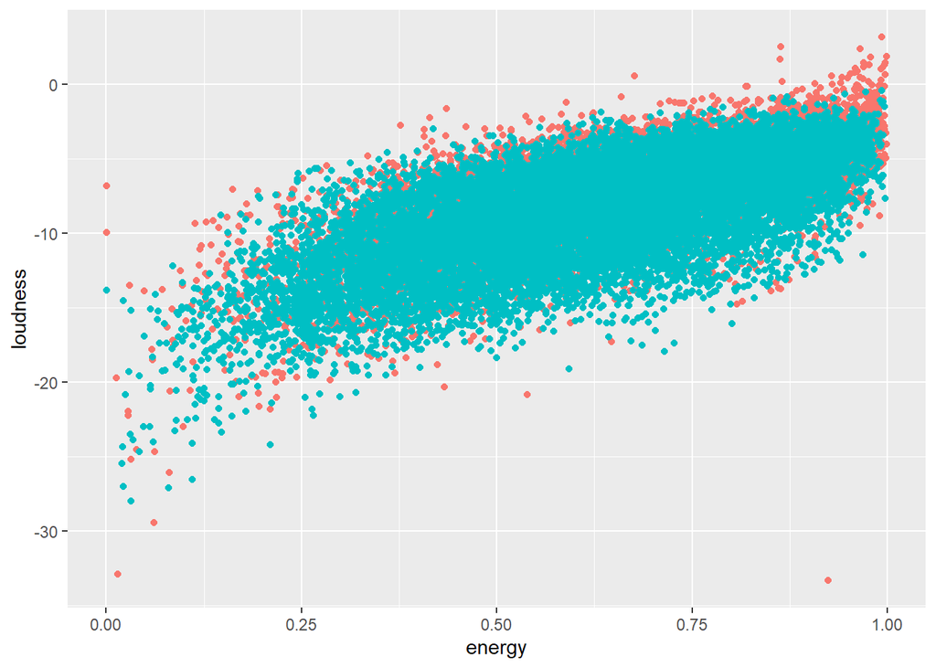

```r
#considering the relationship between energy and loudness
training %>%
  ggplot(., aes(x=energy, y=loudness, color=Is_hit)) +
  geom_point() +
  theme(legend.position="none")
```

- relationship of duration and tempo :

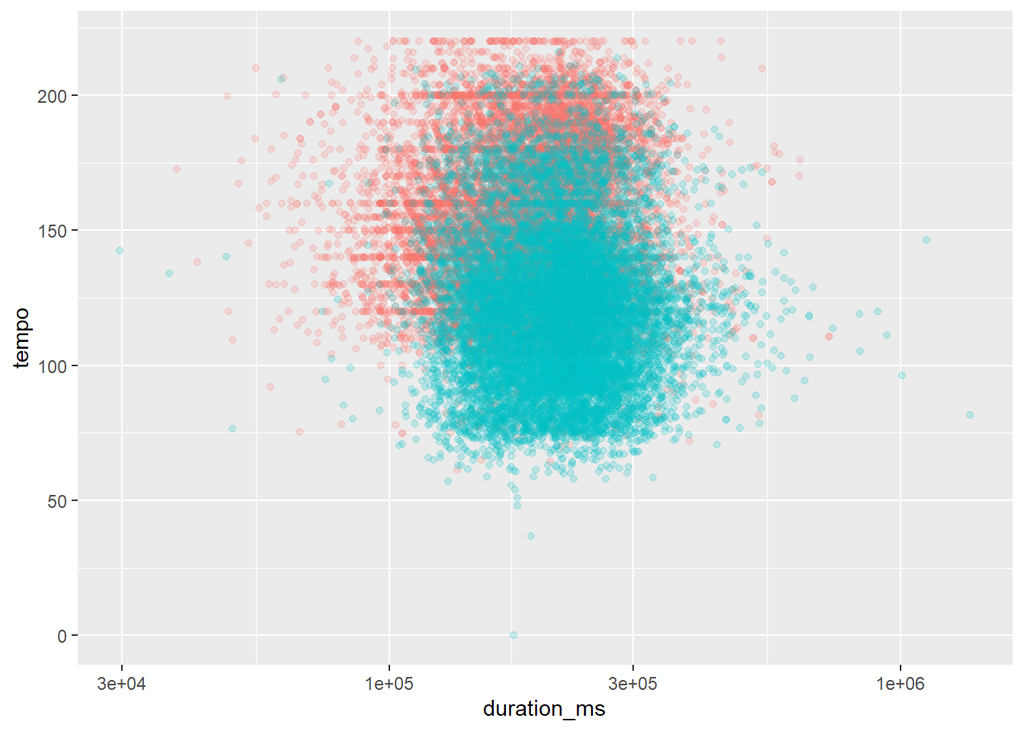

```r
#considering the relationship between tempo and duration
training %>%
  ggplot(., aes(x=duration_ms, y=tempo, color=Is_hit)) +
  geom_point(alpha = 0.2) +
  theme(legend.position="none")+
  scale_x_log10()
```

## Features selection

The previous analysis provided two sets of possible features that can be used in the models as follows:

- by song type
- by song speed

A third alternative taken was looking for automated feature selection using the package Boruta.

[Boruta](https://cran.r-project.org/web/packages/Boruta/Boruta.pdf) uses Random Forest. The method performs a top-down search for relevant features by comparing original attributes’ importance with importance achievable at random, estimated using their permuted copies, and progressively eliminating irrelevant features to stabilise that test. It uses statistically significance to decide the order of the features.

This provided a third set of features to be then subsequently tested in various potential models. The following code was used:

```r
#considering the relationship between tempo and duration
# a) Feature Selection

#creating indexes to evaluate features
colnames(training)
features_index_plusclass <- c(3, 5:17,20)

#define test data to check run time before running the full feature selection model
set.seed(75)
test_data <- sample_n(training[,features_index_plusclass],500)

#considering automated feature selection
# test train the model for first model group
set.seed(75)
startTime <- Sys.time()
boruta_music <- Boruta(Is_hit ~ ., data=na.omit(test_data), doTrace=0)
endTime <- Sys.time()
print(endTime - startTime)
print((as.numeric(endTime - startTime)/500)*26650)

#if execution time from test is acceptable run the  model over full data
# obtaining significant variables

set.seed(75)
startTime <- Sys.time()
boruta_music <- Boruta(Is_hit ~ ., data=na.omit(training[features_index_plusclass]), doTrace=0)
endTime <- Sys.time()
print(endTime - startTime)

# Getting significant variables including tentative
boruta_signif_vars <- getSelectedAttributes(boruta_music, withTentative = TRUE)
roughFixMod_music <- TentativeRoughFix(boruta_music)
boruta_signif_vars <- getSelectedAttributes(roughFixMod_music)
print(boruta_signif_vars)

colnames(training[features_index_plusclass])

# Variable Importance Scores
imps <- attStats(roughFixMod_music)
imps2 = imps[imps$decision != 'Rejected', c('meanImp', 'decision')]
head(imps2[order(-imps2$meanImp), ])  # descending sort
```

The following result was obtained:

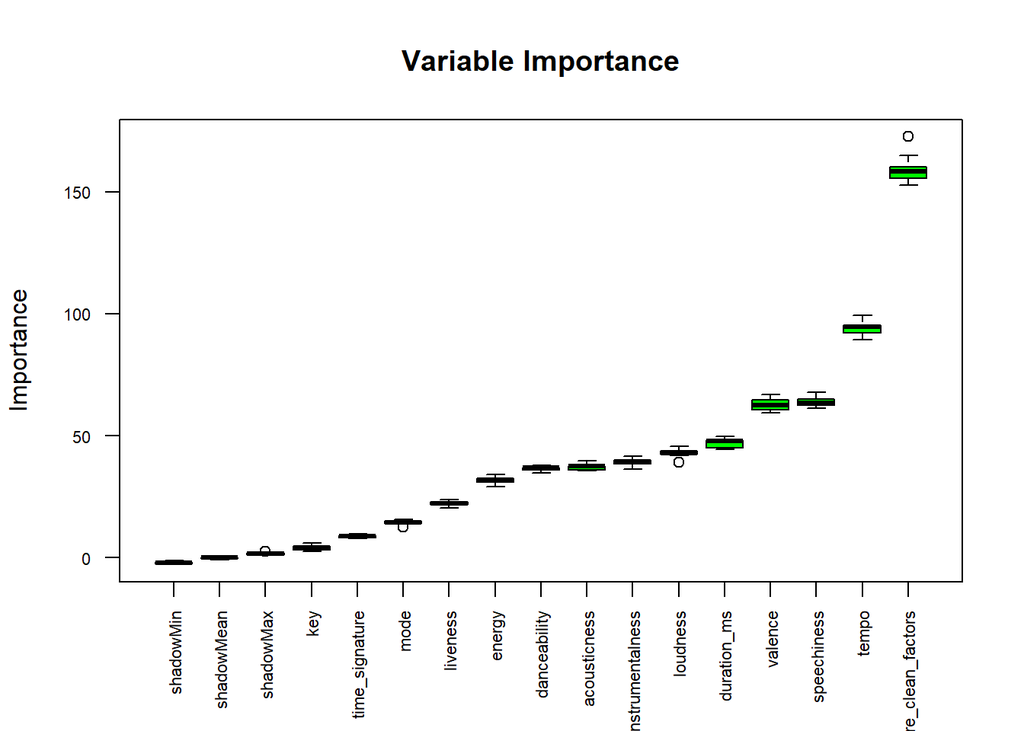

```r
# Plot variable importance
plot(boruta_music, cex.axis=.7, las=2, xlab="", main="Variable Importance")
```

## Data pre-processing

After exploring and visualising the data noted that the following transformations were required:

```r
#Pre-processing: encoding genre factors into a numeric with range 0 to 1

#converting gender range from 0 to 1  the distribution

preProcess_range_model <- preProcess(data.frame(new_negre =as.numeric(training[,c("genre_clean_factors")])), method='range')
new_genre_encoded <- predict(preProcess_range_model, newdata = data.frame(new_negre= as.numeric(training[,c("genre_clean_factors")])))

#appending, checking class and visualising distributions to ensure it remains unaltered

training$new_genre <- new_genre_encoded$new_negre
class(training$new_genre)

par(mfrow=c(1,2))
for(i in 20:21) {
  boxplot(training[,i] ~ training[,3] , main=names(training)[i], las =1, col= c(2,4))

}

##performing same transformation on validation dataset

#converting gender range from 0 to 1  the distribution

preProcess_range_model <- preProcess(data.frame(new_negre =as.numeric(validation[,c("genre_clean_factors")])), method='range')
new_genre_encoded <- predict(preProcess_range_model, newdata = data.frame(new_negre= as.numeric(validation[,c("genre_clean_factors")])))

#appending, checking class and visualising distributions

validation$new_genre <- new_genre_encoded$new_negre
class(validation$new_genre)

par(mfrow=c(1,2))
for(i in 20:21) {
  boxplot(validation[,i] ~ validation[,3] , main=names(validation)[i], las =1, col= c(2,4))

}

#removing objects no longer needed
rm(preProcess_range_model, new_genre_encoded )

##Transforming integers to numeric to avoid issues with caret processing
#checking classes
## variables types
sapply(training, class) %>% as.data.frame(.)

#ensuring that transformation does not affect output
data.frame( trans = unique(as.numeric(training$key)), norm = unique(training$key))
data.frame( trans = unique(as.numeric(training$mode)), norm = unique(training$mode))
data.frame( trans = head(as.numeric(training$duration_ms)), norm = head(training$duration_ms))

#transforming integer variables to numeric in training dataset

training$key <- as.numeric(training$key)
training$mode <- as.numeric(training$mode)
training$duration_ms <-as.numeric(training$duration_ms)

#transforming integer variables to numeric in validation dataset

validation$key <- as.numeric(validation$key)
validation$mode <- as.numeric(validation$mode)
validation$duration_ms <-as.numeric(validation$duration_ms)
```

I selected three sets of potential predictors and created indexes to slice the data, as follows:

- features per song type:

```r
#features of songs characteristics (song types)
type_group_index<- c(3, 21,5,6,11,12,13)
```

```r
#features of songs characteristics (song types)
sapply(training[,type_group_index], class) %>% as.data.frame(.)
```

```
##                        .
## Is_hit            factor
## new_genre        numeric
## key              numeric
## mode             numeric
## speechiness      numeric
## acousticness     numeric
## instrumentalness numeric
```

- features per song speed:

```r
#features of songs speed
speed_group_index <- c(3,7,8, 9,15,16)
```

```r
#features of songs speed
sapply(training[,speed_group_index], class) %>% as.data.frame(.)
```

```
##                    .
## Is_hit        factor
## tempo        numeric
## danceability numeric
## energy       numeric
## valence      numeric
## duration_ms  numeric
```

- features from automated selection (top 6 features):

```r
#from Automated features selection
AFS_group_index <- c(3,21,7, 11, 15,16,10)
```

```r
#from Automated features selection
sapply(training[,AFS_group_index], class) %>% as.data.frame(.)
```

```
##                   .
## Is_hit       factor
## new_genre   numeric
## tempo       numeric
## speechiness numeric
## valence     numeric
## duration_ms numeric
## loudness    numeric
```

To start with the first round of spot checking of algorithms i defined data subsets of 3000 random records to check processing time and potential performance:

```r
#define test data to check run time before running the full feature selection model
set.seed(75)
n_test <- 3000
test_data2 <- sample_n(training[,type_group_index],n_test)

test_data3 <- sample_n(training[,speed_group_index],n_test)

test_data4 <- sample_n(training[,AFS_group_index],n_test)
```

## Spot-Check of Algorithms

Given that this a binary classification problem, I have selected an initial group of algorithms that can be used in this kind of tasks, I consulted various sources to get the following definitions:

- **Logistic Regression:** is a classification algorithm used to assign observations to a discrete set of classes. Logistic regression transforms its output using the logistic sigmoid function to return a probability value
- **k-nearest-neighbor (KNN):** is a data classification method for estimating the likelihood that a data point will become a member of one group or another based on how close the data point is to a nearby group
- **Classification And Regression Trees (CART):** is an algorithm that builds a decision tree based on Gini’s impurity index as splitting criterion. It builds a binary tree by splitting a node into two child nodes repeatedly
- **Naive Bayes:** is a probabilistic classifier based on Bayes’ theorem, which assumes that each feature makes an independent and equal contribution to the probability of a sample belonging to a specific class. It assumes that features do not interact with each other
- **Support Vector Machine (SVM):** is a type of deep learning algorithm that performs supervised learning for classification or regression of data groups. It builds a learning model that assigns new examples to one group or another
- **Random Forest:** is a classification algorithm consisting of many decisions trees. It uses bagging and feature randomness when building each individual tree to try to create an uncorrelated forest of trees whose prediction by committee is more accurate than that of any individual tree

Using the following code I spot-checked these algorithms with each groups of features previously selected, using only a portion of the data (3000 records):

```r
# 10-fold cross validation with 3 repeats
trainControl <- trainControl(method="repeatedcv", number=10, repeats=3, savePredictions = T, classProbs=T)
metric <- "Accuracy"

# Test options and evaluation metric over small subset of data

# considering algorithms for models based on songs characteristics
# LG
set.seed(75)
startTime <- Sys.time()
typegroup.fit.glm <- train(Is_hit ~ ., data = test_data2,  method="glm", metric=metric, trControl=trainControl,  family=binomial(link="logit"), na.action=na.exclude)
endTime <- Sys.time()
print(endTime - startTime)
print((as.numeric(endTime - startTime)/n_test)*26650)

# KNN
set.seed(75)
startTime <- Sys.time()
typegroup.fit.knn <- train(Is_hit ~ ., data=test_data2, method="knn", metric=metric, trControl=trainControl, na.action=na.exclude)
endTime <- Sys.time()
print(endTime - startTime)
print((as.numeric(endTime - startTime)/n_test)*26650)

# CART
set.seed(75)
startTime <- Sys.time()
typegroup.fit.cart <- train(Is_hit ~ ., data=test_data2, method="rpart", metric=metric,
                  trControl=trainControl, na.action=na.exclude)
endTime <- Sys.time()
print(endTime - startTime)
print((as.numeric(endTime - startTime)/n_test)*26650)

# Naive Bayes
set.seed(75)
startTime <- Sys.time()
typegroup.fit.nb <- train(Is_hit ~ ., data=test_data2, method="nb", metric=metric, trControl=trainControl, na.action=na.exclude)
endTime <- Sys.time()
print(endTime - startTime)
print((as.numeric(endTime - startTime)/n_test)*26650)

# SVM
set.seed(75)
startTime <- Sys.time()
typegroup.fit.svm <- train(Is_hit ~ ., data=test_data2, method="svmRadial", metric=metric,
                 trControl=trainControl, na.action=na.exclude)
endTime <- Sys.time()
print(endTime - startTime)
print((as.numeric(endTime - startTime)/n_test)*26650)

# RF
set.seed(75)
startTime <- Sys.time()
typegroup.fit.RF <- train(Is_hit ~ ., data=test_data2, method="rf", ntree=5, metric=metric,
                trControl=trainControl, na.action=na.exclude)
endTime <- Sys.time()
print(endTime - startTime)
print((as.numeric(endTime - startTime)/n_test)*26650)

# considering algorithms for models based on songs speed
# LG
set.seed(75)
startTime <- Sys.time()
speedgroup.fit.glm <- train(Is_hit ~ ., data = test_data3,  method="glm", metric=metric, trControl=trainControl,  preProcess = 'center',  family=binomial(link="logit"), na.action=na.exclude)
endTime <- Sys.time()
print(endTime - startTime)
print((as.numeric(endTime - startTime)/n_test)*26650)

# KNN
set.seed(75)
startTime <- Sys.time()
speedgroup.fit.knn <- train(Is_hit ~ ., data=test_data3, method="knn", metric=metric, trControl=trainControl, na.action=na.exclude)
endTime <- Sys.time()
print(endTime - startTime)
print((as.numeric(endTime - startTime)/n_test)*26650)

# CART
set.seed(75)
startTime <- Sys.time()
speedgroup.fit.cart <- train(Is_hit ~ ., data=test_data3, method="rpart", metric=metric,
                             trControl=trainControl, na.action=na.exclude)
endTime <- Sys.time()
print(endTime - startTime)
print((as.numeric(endTime - startTime)/n_test)*26650)

# Naive Bayes
set.seed(75)
startTime <- Sys.time()
speedgroup.fit.nb <- train(Is_hit ~ ., data=test_data3, method="nb", metric=metric, trControl=trainControl, na.action=na.exclude)
endTime <- Sys.time()
print(endTime - startTime)
print((as.numeric(endTime - startTime)/n_test)*26650)

# SVM
set.seed(75)
startTime <- Sys.time()
speedgroup.fit.svm <- train(Is_hit ~ ., data=test_data3, method="svmRadial", metric=metric,
                            trControl=trainControl, na.action=na.exclude)
endTime <- Sys.time()
print(endTime - startTime)
print((as.numeric(endTime - startTime)/n_test)*26650)

# RF
set.seed(75)
startTime <- Sys.time()
speedgroup.fit.RF <- train(Is_hit ~ ., data=test_data3, method="rf", ntree=5, metric=metric,
                           trControl=trainControl, na.action=na.exclude)

endTime <- Sys.time()
print(endTime - startTime)
print((as.numeric(endTime - startTime)/n_test)*26650)

# considering algorithms for models based on automated features selection

# LG  (with preprocess set to center to normalise the predictors as its beneficial for Logistic regression)
set.seed(75)
startTime <- Sys.time()
AFSgroup.fit.glm <- train(Is_hit ~ ., data = test_data4,  method="glm", metric=metric, trControl=trainControl, preProcess = 'center', family=binomial(link="logit"), na.action=na.exclude)
endTime <- Sys.time()
print(endTime - startTime)
print((as.numeric(endTime - startTime)/n_test)*26650)

# KNN
set.seed(75)
startTime <- Sys.time()
AFSgroup.fit.knn <- train(Is_hit ~ ., data=test_data4, method="knn", metric=metric, trControl=trainControl, na.action=na.exclude)
endTime <- Sys.time()
print(endTime - startTime)
print((as.numeric(endTime - startTime)/n_test)*26650)

# CART
set.seed(75)
startTime <- Sys.time()
AFSgroup.fit.cart <- train(Is_hit ~ ., data=test_data4, method="rpart", metric=metric,
                           trControl=trainControl, na.action=na.exclude)
endTime <- Sys.time()
print(endTime - startTime)
print((as.numeric(endTime - startTime)/n_test)*26650)

# Naive Bayes
set.seed(75)
startTime <- Sys.time()
AFSgroup.fit.nb <- train(Is_hit ~ ., data=test_data4, method="nb", metric=metric, trControl=trainControl, na.action=na.exclude)
endTime <- Sys.time()
print(endTime - startTime)
print((as.numeric(endTime - startTime)/n_test)*26650)

# SVM
set.seed(75)
startTime <- Sys.time()
AFSgroup.fit.svm <- train(Is_hit ~ ., data=test_data4, method="svmRadial", metric=metric,
                          trControl=trainControl, na.action=na.exclude)
endTime <- Sys.time()
print(endTime - startTime)
print((as.numeric(endTime - startTime)/n_test)*26650)

# RF
set.seed(75)
startTime <- Sys.time()
AFSgroup.fit.RF <- train(Is_hit ~ ., data=test_data4, method="rf", ntree=5, metric=metric,
                         trControl=trainControl, na.action=na.exclude)
endTime <- Sys.time()
print(endTime - startTime)
print((as.numeric(endTime - startTime)/n_test)*26650)

# Compare algorithms
results <- resamples(list(LG_type=typegroup.fit.glm, LG_speed=speedgroup.fit.glm, LG_AFS=AFSgroup.fit.glm,
                          KNN_type=typegroup.fit.knn, KNN_speed=speedgroup.fit.knn, KNN_AFS=AFSgroup.fit.knn,
                          CART_type=typegroup.fit.cart, CART_speed=speedgroup.fit.cart, CART_AFS=AFSgroup.fit.cart,
                          NB_type=typegroup.fit.nb, NB_speed=speedgroup.fit.nb, NB_AFS=AFSgroup.fit.nb,
                          SVM_type=typegroup.fit.svm, SVM_speed=speedgroup.fit.svm, SVM_AFS=AFSgroup.fit.svm,
                          RF_type=typegroup.fit.RF, RF_speed=speedgroup.fit.RF, RF_AFS=AFSgroup.fit.RF))
```

The following results were noted:

```r
#spot check of models
summary(results)
```

```
##
## Call:
## summary.resamples(object = results)
##
## Models: LG_type, LG_speed, LG_AFS, KNN_type, KNN_speed, KNN_AFS, CART_type, CART_speed, CART_AFS, NB_type, NB_speed, NB_AFS, SVM_type, SVM_speed, SVM_AFS, RF_type, RF_speed, RF_AFS
## Number of resamples: 30
##
## Accuracy
##                 Min.   1st Qu.    Median      Mean   3rd Qu.      Max. NA's
## LG_type    0.7433333 0.7750000 0.8033333 0.7963333 0.8100000 0.8433333    0
## LG_speed   0.7826087 0.8166667 0.8277592 0.8257682 0.8366667 0.8566667    0
## LG_AFS     0.8300000 0.8487154 0.8666667 0.8635695 0.8704319 0.9000000    0
## KNN_type   0.7700000 0.7900000 0.8116667 0.8064444 0.8200000 0.8400000    0
## KNN_speed  0.4866667 0.5270598 0.5492475 0.5488954 0.5694048 0.6066667    0
## KNN_AFS    0.5016722 0.5453045 0.5592642 0.5612122 0.5828488 0.6066667    0
## CART_type  0.9566667 0.9733333 0.9766667 0.9770000 0.9800000 0.9933333    0
## CART_speed 0.7100000 0.7500000 0.7700000 0.7632017 0.7826827 0.8073090    0
## CART_AFS   0.8361204 0.8782358 0.8935105 0.8933197 0.9066667 0.9297659    0
## NB_type    0.7500000 0.7808333 0.7983333 0.7971111 0.8191667 0.8366667    0
## NB_speed   0.7600000 0.8133333 0.8269546 0.8243230 0.8370736 0.8566667    0
## NB_AFS     0.7940199 0.8269231 0.8452547 0.8437816 0.8590468 0.8933333    0
## SVM_type   0.7800000 0.8025000 0.8166667 0.8171111 0.8291667 0.8600000    0
## SVM_speed  0.7792642 0.8300000 0.8369380 0.8374279 0.8525000 0.8666667    0
## SVM_AFS    0.8662207 0.8829431 0.8966667 0.8943279 0.9035742 0.9130435    0
## RF_type    0.9533333 0.9833333 0.9866667 0.9867778 0.9900000 1.0000000    0
## RF_speed   0.7692308 0.8008333 0.8133313 0.8123278 0.8250000 0.8466667    0
## RF_AFS     0.9667774 0.9808692 0.9866444 0.9860073 0.9900000 1.0000000    0
##
## Kappa
##                    Min.    1st Qu.     Median       Mean   3rd Qu.      Max.
## LG_type     0.485981308 0.55017422 0.60650893 0.59239506 0.6198733 0.6869171
## LG_speed    0.565163889 0.63323552 0.65549561 0.65154959 0.6733551 0.7133333
## LG_AFS      0.659788313 0.69727774 0.73329747 0.72703271 0.7407636 0.7998221
## KNN_type    0.540122634 0.57988761 0.62321034 0.61289776 0.6401200 0.6798719
## KNN_speed  -0.027077498 0.05409617 0.09841922 0.09770447 0.1387703 0.2132984
## KNN_AFS     0.001613518 0.09061395 0.11681164 0.12147830 0.1655194 0.2127735
## CART_type   0.913448735 0.94665955 0.95332089 0.95400864 0.9600160 0.9866649
## CART_speed  0.420000000 0.50015536 0.54000000 0.52650514 0.5653015 0.6146307
## CART_AFS    0.673936750 0.75685468 0.78752761 0.78696138 0.8136791 0.8594768
## NB_type     0.497184232 0.55980484 0.59496700 0.59259059 0.6372809 0.6718457
```

[output cut: 12 more lines]

```
## KNN_type      0
## KNN_speed     0
## KNN_AFS       0
## CART_type     0
## CART_speed    0
## CART_AFS      0
## NB_type       0
## NB_speed      0
## NB_AFS        0
## SVM_type      0
## SVM_speed     0
## SVM_AFS       0
## RF_type       0
## RF_speed      0
## RF_AFS        0
```

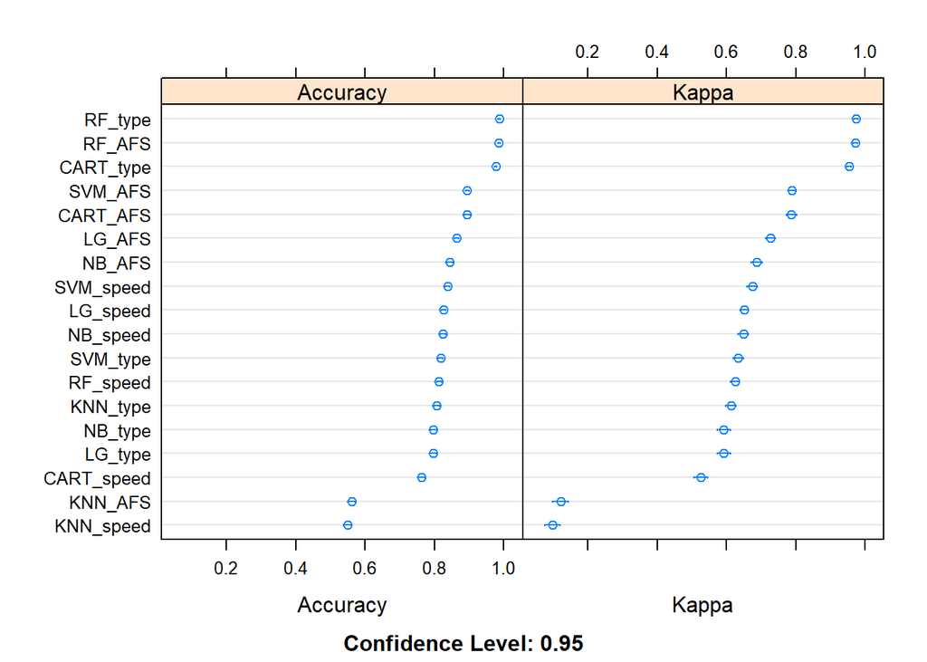

```r
dotplot(results)
```

## Evaluating Selected Algorithms

Based on the above cross-validated results over the subset data, and considering processing time, I have selected the following models for consideration over the full dataset:

```r
# Checking performance with full training dataset to select best models

# RF type
set.seed(75)
startTime <- Sys.time()
typegroup.fit.RF2 <- train(Is_hit ~ ., data=training[,type_group_index], method="rf", ntree=5, metric=metric,
                          trControl=trainControl, na.action=na.exclude)
endTime <- Sys.time()
print(endTime - startTime)


# RF AFS
set.seed(75)
startTime <- Sys.time()
AFSgroup.fit.RF2 <- train(Is_hit ~ ., data=training[,AFS_group_index], method="rf", ntree=5, metric=metric,
                         trControl=trainControl, na.action=na.exclude, preProcess= "center")
endTime <- Sys.time()
print(endTime - startTime)

# CART Type
set.seed(75)
startTime <- Sys.time()
typegroup.fit.cart2 <- train(Is_hit ~ ., data=training[,type_group_index], method="rpart", metric=metric,
                            trControl=trainControl, na.action=na.exclude, preProcess= "center")
endTime <- Sys.time()
print(endTime - startTime)

#SVM_AFS excluded due to long processing time

# CART AFS
set.seed(75)
startTime <- Sys.time()
AFSgroup.fit.cart2 <- train(Is_hit ~ ., data=training[,AFS_group_index], method="rpart", metric=metric,
                             trControl=trainControl, na.action=na.exclude, preProcess= "center")
endTime <- Sys.time()
print(endTime - startTime)

# LG  AFS
set.seed(75)
startTime <- Sys.time()
AFSgroup.fit.glm2 <- train(Is_hit ~ ., data = training[,AFS_group_index],  method="glm", metric=metric, trControl=trainControl, family=binomial(link="logit"), na.action=na.exclude,  preProcess= "center")
endTime <- Sys.time()
print(endTime - startTime)

# Compare first selection of algorithms
results_fisrt_select <- resamples(list(RF_type=typegroup.fit.RF,RF_AFS=AFSgroup.fit.RF,
                                       CART_type=typegroup.fit.cart, CART_AFS=AFSgroup.fit.cart,
                                       LG_AFS=AFSgroup.fit.glm, RF_type2=typegroup.fit.RF2,RF_AFS2=AFSgroup.fit.RF2,
                                       CART_type2=typegroup.fit.cart2, CART_AFS2=AFSgroup.fit.cart2,
                                       LG_AFS2=AFSgroup.fit.glm2))
```

```r
#spot check of models
summary(results_fisrt_select)
```

```
##
## Call:
## summary.resamples(object = results_fisrt_select)
##
## Models: RF_type, RF_AFS, CART_type, CART_AFS, LG_AFS, RF_type2, RF_AFS2, CART_type2, CART_AFS2, LG_AFS2
## Number of resamples: 30
##
## Accuracy
##                 Min.   1st Qu.    Median      Mean   3rd Qu.      Max. NA's
## RF_type    0.9533333 0.9833333 0.9866667 0.9867778 0.9900000 1.0000000    0
## RF_AFS     0.9667774 0.9808692 0.9866444 0.9860073 0.9900000 1.0000000    0
## CART_type  0.9566667 0.9733333 0.9766667 0.9770000 0.9800000 0.9933333    0
## CART_AFS   0.8361204 0.8782358 0.8935105 0.8933197 0.9066667 0.9297659    0
## LG_AFS     0.8300000 0.8487154 0.8666667 0.8635695 0.8704319 0.9000000    0
## RF_type2   0.9988743 0.9992496 0.9996248 0.9995497 0.9999062 1.0000000    0
## RF_AFS2    0.9943715 0.9973724 0.9977482 0.9975485 0.9981244 0.9992495    0
## CART_type2 0.9741088 0.9787115 0.9834897 0.9834147 0.9886502 0.9909944    0
## CART_AFS2  0.8912228 0.8983766 0.9078970 0.9286556 0.9624765 0.9677298    0
## LG_AFS2    0.8716698 0.8803940 0.8835334 0.8827018 0.8864809 0.8927232    0
##
## Kappa
##                 Min.   1st Qu.    Median      Mean   3rd Qu.      Max. NA's
## RF_type    0.9067040 0.9666667 0.9733369 0.9735558 0.9800000 1.0000000    0
## RF_AFS     0.9335805 0.9617401 0.9732856 0.9720109 0.9799947 1.0000000    0
## CART_type  0.9134487 0.9466596 0.9533209 0.9540086 0.9600160 0.9866649    0
## CART_AFS   0.6739368 0.7568547 0.7875276 0.7869614 0.8136791 0.8594768    0
## LG_AFS     0.6597883 0.6972777 0.7332975 0.7270327 0.7407636 0.7998221    0
## RF_type2   0.9977486 0.9984992 0.9992495 0.9990995 0.9998125 1.0000000    0
## RF_AFS2    0.9887430 0.9947447 0.9954963 0.9950969 0.9962487 0.9984991    0
## CART_type2 0.9482175 0.9574229 0.9669794 0.9668294 0.9773003 0.9819886    0
## CART_AFS2  0.7824456 0.7967562 0.8157885 0.8573129 0.9249527 0.9354593    0
## LG_AFS2    0.7433423 0.7607897 0.7670668 0.7654039 0.7729623 0.7854464    0
```

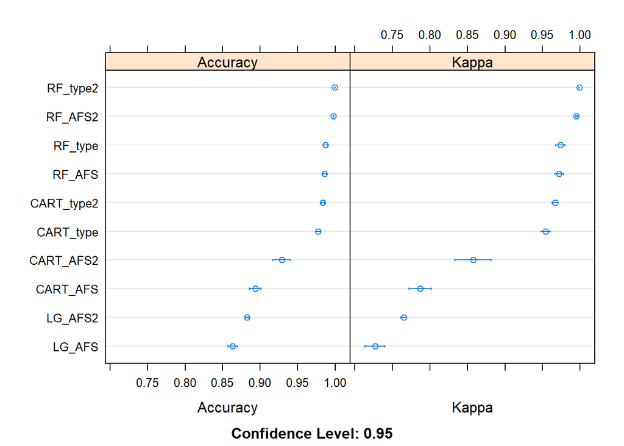

```r
dotplot(results_fisrt_select)
```

I evaluated the performance of these models over the validation dataset to check if there was any tendency to overfit. I defined a function to expedite the calculation of the confusion matrix and obtain a summary of the results:

```r
###Checking for possible overfitting of the models

#defining a function to check performance with validation dataset
validation_function <- function(x,y) {
  predict_test <-predict(x, newdata=y)
  a <- confusionMatrix(predict_test,y$Is_hit)
  b<- data.frame(row.names = "results", acc = a$overall['Accuracy'],
                 pval= a$overall['AccuracyPValue'],
                 sen= a$byClass['Sensitivity'],
                 spe = a$byClass['Specificity'],
                 f1= a$byClass['F1'])
  return(b)
}

#summarising results

selected_models <- list(RF_type2=typegroup.fit.RF2,RF_AFS2=AFSgroup.fit.RF2,
                        CART_type2=typegroup.fit.cart2, CART_AFS2=AFSgroup.fit.cart2,
                        LG_AFS2=AFSgroup.fit.glm2)
```

The following results were noted:

```r
#checking for overfitting:
sapply(selected_models, validation_function, y = validation)
```

```
##      RF_type2     RF_AFS2      CART_type2 CART_AFS2 LG_AFS2
## acc  0.5954668    0.6154308    0.7997598  0.8980787 0.8818673
## pval 2.676074e-55 4.222582e-80 0          0         0
## sen  0.2080456    0.2482738    0.6346443  0.981387  0.8916241
## spe  0.982888     0.9825878    0.9648754  0.8147703 0.8721105
## f1   0.3396226    0.392315     0.7601582  0.9059166 0.8830088
```

I noted that the Random Forest models were significantly over-fitted and not performing well for sensitivity. Similarly the Cart for the type-group features was showing signals of overfitting and lower sensitivity than specificity. Therefore I discarded these models.

I selected the following models as they had higher accuracy and performed well in both sensitivity and specificity:

- CART over automated selected features group.
- Logistic Regression over automated selected features group.

## Interpretation of individual final models selected

**CART**

The CART model created a binary tree by using two features: genre and tempo, as noted below:

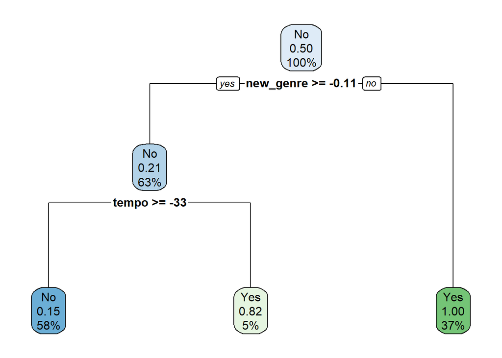

```r
#plotting the tree produced by the Cart model:
#AFS.CART
rpart.plot(AFSgroup.fit.cart2$finalModel)
```

Interpretation has been a bit obscured due to data transformation. We applied “Preprocess = center” to the data in the processing of the models. This subtracts the mean of the predictor’s data from each data point. We have also transformed the categorical variable “genre” to a numerical vector for ease of use in the model.

The tree starts indicating that classes are balanced (“No” represents 50% of the classes)

The model performs a cutoff at certain genres and divides the population between hit (about 37% of the songs are classified as hits based on genre grouping) and the remaining 63% is further evaluated using the tempo feature.

For tempo we know that the mean is 136.5:

```r
#Tempo mean
mean(training$tempo)
```

```
## [1] 136.5239
```

**LOGISTIC REGRESSION**

Logistic regression models are based on the logistic function:

$$\frac{1}{(1 + e^{-value})}$$

Where:

- e represents the base of the natural logarithms
- value is the numerical value that we want to transform.

This can also be represented this way:

$$g(p) = log(\frac{p}{1−p})$$

Our Logistic regression model has six predictor and can be represented as follows:

$$g\langle p(x1, x2...x6)\rangle = g\langle Pr(Y = 1 | X1 = x1,X2 = x2, \cdots, X6 = x6)\rangle = \beta0 + \beta1x1 + \beta2x2+ \cdots + \beta6x6$$

Another way to look at it is:

$$y =\frac {e^{(\beta0 + \beta1*X1 + \beta2*x2+ \cdots +\beta6*x6)}} {(1 + e^{(\beta0 + \beta1*X + \beta2*x2 + \cdots + \beta6*x6)})}$$

Where:

- x1 to x6 are the six predictors placed in our model.

The Logistic Regression model summary provides a detail of the coefficients calculated for each variable:

```r
#AFS.GLM
summary(AFSgroup.fit.glm2)
```

```
##
## Call:
## NULL
##
## Deviance Residuals:
##     Min       1Q   Median       3Q      Max
## -3.3342  -0.3626  -0.0015   0.2905   3.4152
##
## Coefficients:
##               Estimate Std. Error z value Pr(>|z|)
## (Intercept)  7.508e-02  2.187e-02   3.434 0.000596 ***
## new_genre   -6.327e+00  1.009e-01 -62.686  < 2e-16 ***
## tempo       -3.779e-02  7.841e-04 -48.189  < 2e-16 ***
## speechiness -4.509e+00  2.032e-01 -22.187  < 2e-16 ***
## valence      5.145e+00  9.865e-02  52.158  < 2e-16 ***
## duration_ms  9.322e-06  3.727e-07  25.014  < 2e-16 ***
## loudness    -9.295e-02  6.702e-03 -13.868  < 2e-16 ***
## ---
## Signif. codes:  0 '***' 0.001 '**' 0.01 '*' 0.05 '.' 0.1 ' ' 1
##
## (Dispersion parameter for binomial family taken to be 1)
##
##     Null deviance: 36945  on 26649  degrees of freedom
## Residual deviance: 14637  on 26643  degrees of freedom
## AIC: 14651
##
## Number of Fisher Scoring iterations: 6
```

Please note that p-values are very low, indicating that there is relationship between the target variable (“Is_hit”) and the predictors (i.e. rejecting the null hypothesis that changes in the predictors have no effect in the target variable).

In general, negative coefficients will indicate a decrease in the probability of the song being classified as a hit, when there is an increase in the predictor’s value.

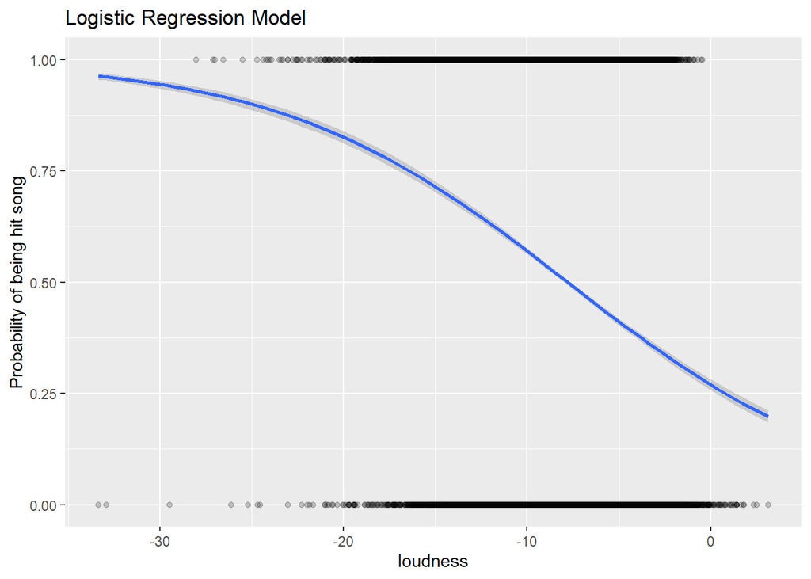

```r
#AFS.GLM
#probability curve for loudness example
training[,AFS_group_index]  %>%
  mutate(prob = ifelse(Is_hit == "Yes", 1, 0)) %>%
  ggplot(aes(loudness, prob)) +
  geom_point(alpha = 0.2) +
  geom_smooth(method = "glm", method.args = list(family = "binomial")) +
  labs(
    title = "Logistic Regression Model",
    x = "loudness",
    y = "Probability of being hit song"
  )
```

Positive coefficients indicate an increase in the probability of the song being classified as a hit, when there is an increase in the predictor’s value.

An example is the duration feature. An increase on duration tends to increase the probability of the song being a hit, this need to be read carefully with the standard deviation as a sign of variability:

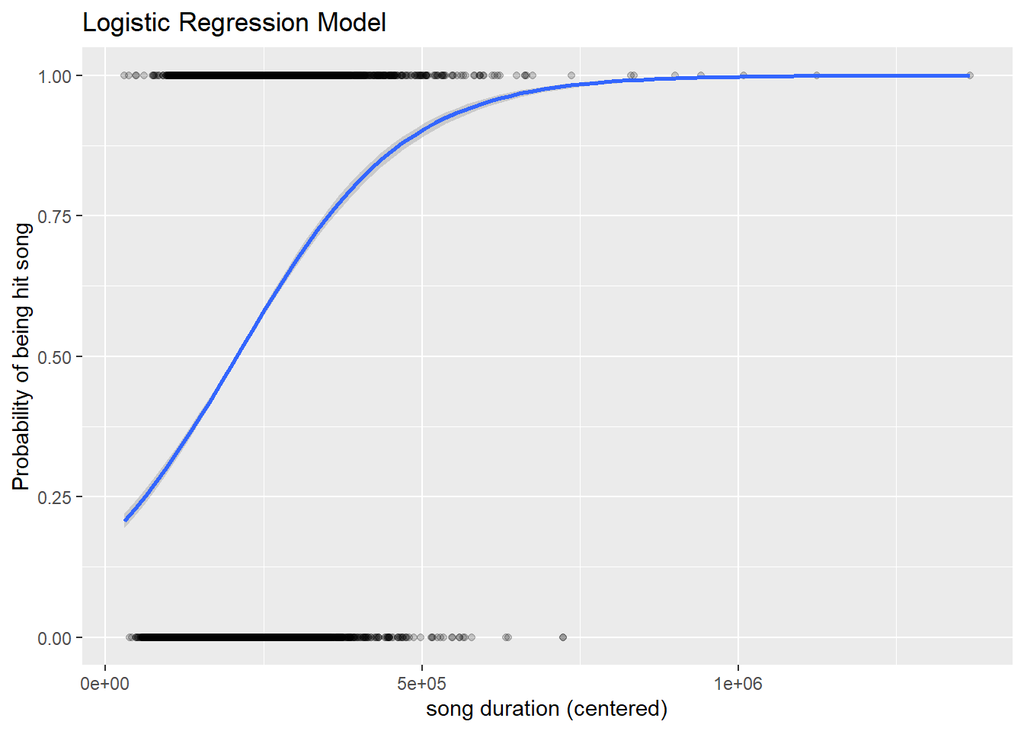

```r
#AFS.GLM
#probability curve for duration example
training[,AFS_group_index]  %>%
  mutate(prob = ifelse(Is_hit == "Yes", 1, 0)) %>%
  ggplot(aes(duration_ms, prob)) +
  geom_point(alpha = 0.2) +
  geom_smooth(method = "glm", method.args = list(family = "binomial")) +
  labs(
    title = "Logistic Regression Model",
    x = "song duration (centered)",
    y = "Probability of being hit song"
  )
```

- grouping data and creating the layouts

```r
###expanding on genres interpretation

### visualization of Top15 genres by class
Top_15_genre_hit <- by_genre_count %>% filter(Is_hit == 1) %>% arrange(desc(total_songs)) %>% head(15)

Top_15_genre_non_hit <- by_genre_count %>% filter(Is_hit == 0) %>% arrange(desc(total_songs)) %>% head(15)


# Generate the layout for Top_15_genre_hit
packing <- circleProgressiveLayout(Top_15_genre_hit$total_songs, sizetype='area')
packing$radius <- 0.95*packing$radius
Top_15_genre_hit_pack <- cbind(Top_15_genre_hit, packing)
Top_15_genre_hit_pack.gg <- circleLayoutVertices(packing, npoints=50)

# Generate the layout for Top_15_genre_non_hit
packing_nh <- circleProgressiveLayout(Top_15_genre_non_hit$total_songs, sizetype='area')
packing_nh$radius <- 0.95*packing$radius
Top_15_genre_non_hit_pack <- cbind(Top_15_genre_non_hit, packing_nh)
Top_15_genre_non_hit_pack.gg <- circleLayoutVertices(packing_nh, npoints=50)
```

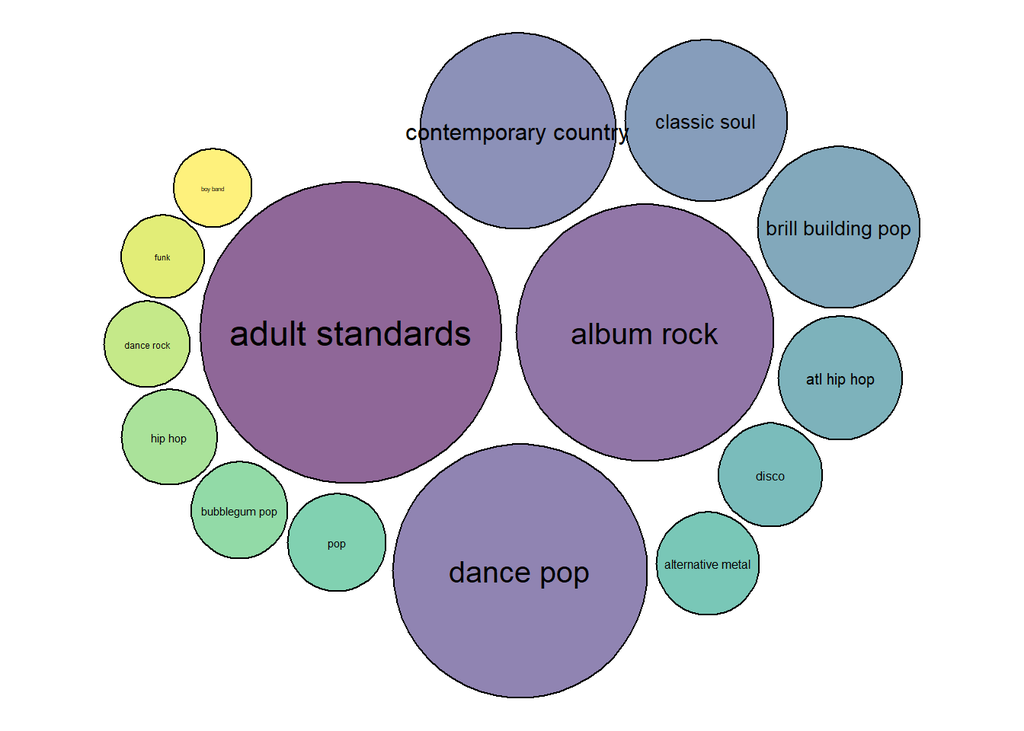

```r
# Plot Top_15_genre_hit
ggplot() +
  geom_polygon(data = Top_15_genre_hit_pack.gg, aes(x, y, group = id, fill=id), colour = "black", alpha = 0.6) +
  scale_fill_viridis() +
  geom_text(data = Top_15_genre_hit_pack, aes(x, y, size=total_songs, label = genre_clean_factors), color="black") +
  theme_void() +
  theme(legend.position="none")+
  coord_equal()
```

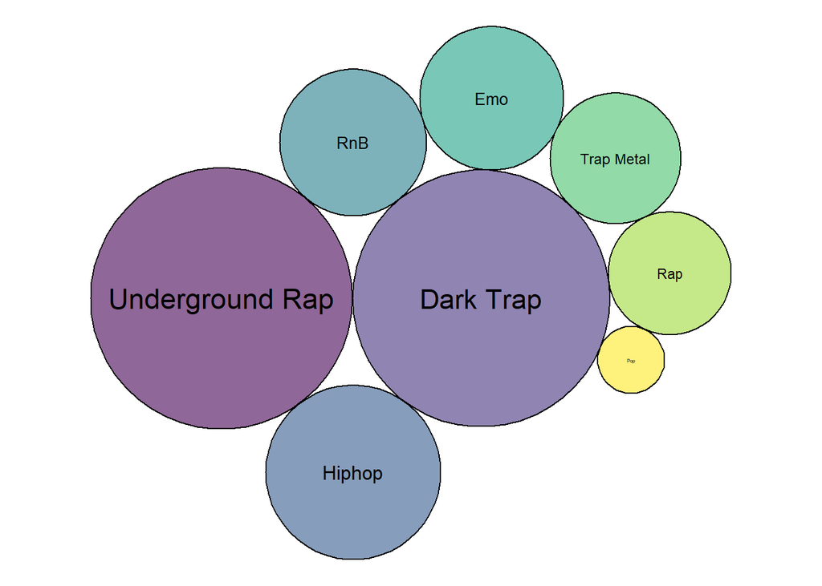

```r
# Plot Top_15_genre_hit
ggplot() +
  geom_polygon(data = Top_15_genre_non_hit_pack.gg, aes(x, y, group = id, fill=id), colour = "black", alpha = 0.6) +
  scale_fill_viridis() +
  geom_text(data = Top_15_genre_non_hit_pack, aes(x, y, size=total_songs, label = genre_clean_factors), color="black") +
  theme_void() +
  theme(legend.position="none")+
  coord_equal()
```

## Final model ensemble and evaluation

Given that both models performed similarly, I explored an ensemble of these models to obtain an improved accuracy, while maintaining reasonable performance in sensitivity and specificity.

I listed the two models to ensemble with the following code:

```r
#ensemble of two models selected

model_list <- caretList(
  Is_hit~., data=training[,AFS_group_index],
  trControl=trainControl,
  methodList=c("glm", "rpart")
)
```

and checked whether models were correlated. If the models are correlated it means they are predicting mistakes in the same way, therefore it won’t be useful to ensemble them. However, the following code shows that the models have low correlation:

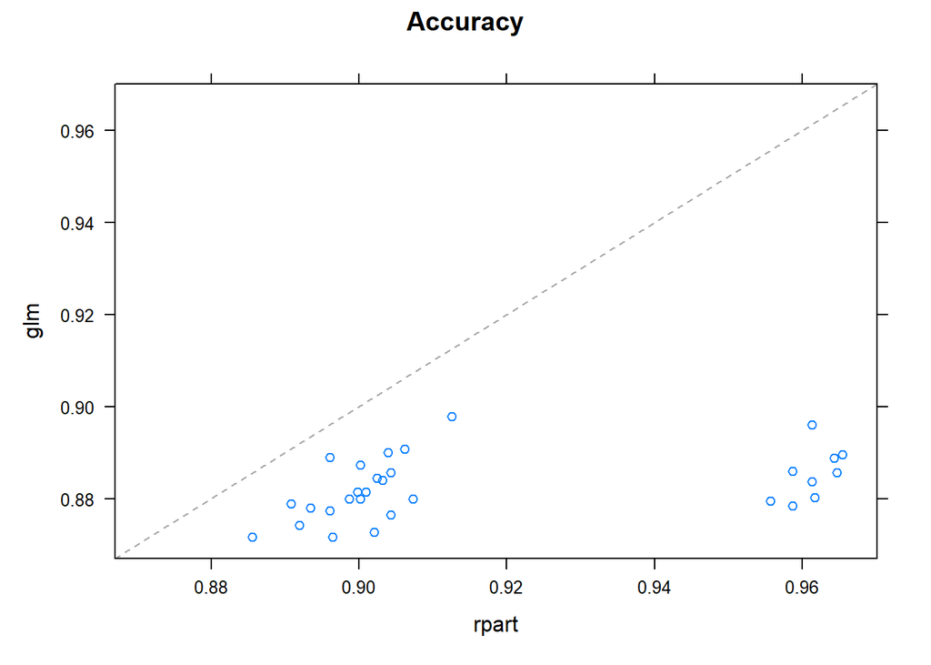

```r
#checking  models correlation
xyplot(resamples(model_list))
```

```r
modelCor(resamples(model_list))
```

```
##             glm     rpart
## glm   1.0000000 0.3705314
## rpart 0.3705314 1.0000000
```

The following code allowed me to ensemble the models:

```r
#ensemble
ensemble_ctrl <- trainControl(method = "repeatedcv", number = 10, repeats=3, returnResamp = "final",
                              savePredictions = "final",  classProbs = TRUE)

final_model <- caretEnsemble(
  model_list,
  metric="Accuracy",
  trControl= ensemble_ctrl)
```

The new model produce a higher level of accuracy than the individual models:

```r
#final model
summary(final_model)
```

```
## The following models were ensembled: glm, rpart
## They were weighted:
## 5.4888 -4.2845 -5.264
## The resulting Accuracy is: 0.9304
## The fit for each individual model on the Accuracy is:
##  method  Accuracy AccuracySD
##     glm 0.8827016 0.00666575
##   rpart 0.9182874 0.02918040
```

The following code demonstrates how the model assigns importance levels to each of the predictors:

```r
#importance of predictors
final_model_imp<- varImp(final_model)

final_model_imp[order(final_model_imp$overall,decreasing=TRUE),]
```

```
##               overall       glm     rpart
## new_genre   42.561698 34.649207 49.001771
## tempo       22.634385 24.359242 21.230503
## valence     17.182572 27.176409  9.048465
## speechiness 11.656772  5.904258 16.338814
## duration_ms  5.964573  7.910884  4.380447
## loudness     0.000000  0.000000  0.000000
```

Finally, I evaluated the model performance using the validation dataset and compared it with the performance of the individual models. We can see that the accuracy level has increased, while maintaining an acceptable level of performance with sensitivity and accuracy.

```r
#evaluating models with validation dataset

#final model
validation_function(final_model ,validation)
```

```
##               acc pval       sen       spe       f1
## results 0.9187932    0 0.9510657 0.8865206 0.921332
```

```r
#individual models
validation_function(AFSgroup.fit.cart2 ,validation)
```

```
##               acc pval      sen       spe        f1
## results 0.8980787    0 0.981387 0.8147703 0.9059166
```

```r
validation_function(AFSgroup.fit.glm2 ,validation)
```

```
##               acc pval       sen       spe        f1
## results 0.8818673    0 0.8916241 0.8721105 0.8830088
```

## CONCLUSION AND LIMITATIONS

The project aim was to predict a hit song based on its audio feature. This was a binary classification problem, with a base probability of 50% (affected by prevalence of the classes).

The analysis performed indicates that popular songs, which we call “hit songs” under the term of this project, share certain characteristics that allow for distinctions with non-hit songs.

The model indicates that the most relevant audio features to predict hit songs are:

- genre
- tempo
- valence
- speechiness
- duration_ms
- loudness

I was able to construct an model that provides an overall accuracy of approx. 91% while maintaining sensitivity and specificity over 88%.

To perform the analysis I have maintained the classes balanced. The intention was to eliminate any influence that unbalanced classes could have on the modelling. However, the reality might differ significantly. By intuition we can say that there is a lower portion of successful songs in the total universe of songs composed.

I am unable to assess that proportion as part of this study. However, potentially this could be assessed by looking at sample proportions of other studies performed on hit/non-hot songs or taking several samples across populations of songs and averaging the proportion of successful songs.

To test the efficacy of my final model, I sliced the validation dataset and created an arbitrary unbalanced test set (10% hits vs 90% non-hit songs) with the following code:

```r
#testing final model on unbalanced dataset
(set.seed = 75)
validation_unbalanced_no <- validation %>% filter(Is_hit == "No") %>% sample_n(., 3000)
validation_unbalanced_yes <- validation %>% filter(Is_hit == "Yes") %>% sample_n(., 300)

validation_unbalanced <- rbind(validation_unbalanced_no, validation_unbalanced_yes) %>% arrange(.$track_id)
```

When testing the final model to the unbalanced dataset we can see that the level of accuracy increases and maintains an good levels of sensibility and specificity:

```r
#testing algorithm in unbalanced population
validation_function(final_model,validation_unbalanced)
```

```
##               acc         pval       sen       spe        f1
## results 0.9454545 4.393963e-15 0.9506667 0.8933333 0.9694086
```

**Other limitations and possible further work**

We might be able to predict potential hit songs using these characteristics, but it does not imply causality (i.e. these audio features will not necessarily make the song a hit). There could be other confounding factors that are driving the success of certain songs, which were not subject of my analysis.

To establish whether or not a causal relationship exists between the success of the song and its characteristics we would need to include data about those potential confounders (such as marketing, artist trajectory/ability, record company reputation, etc.) to control and account for its effect.

The analysis can be expanded by looking at the characteristics of songs within specific genres to identify the audio features of hit songs for particular genres of interest.

Other features could be considered, for example genre is related to aspects such as specific instrumentation (selection of instruments included in a song), this could be a variable to add. Other variables could be about the quality of the sound: masterization and mix, etc. This would require a measurement of these variables, which at the moment are not available in Spotify data.

Analysis can also be expanded to include geographical, socioeconomic and or audience profile data to stratify further the preference of the public. Also, we could study an specific period as it is expected that taste and preference would fluctuate over time.